# Determinantes

yo

3/7/2021

## Determinante de una matriz cuadrada

**Determinante.** Dada una **matriz cuadrada** $A\in\mathcal{M}_n(\mathbb{K})$, llamaremos determinante de la matriz $A$ y lo escribiremos como $\det(A)$ o $|A|$ a un elemento del cuerpo $\mathbb{K}$ que se define por inducción del siguiente modo:

- si $n=1$ **o con una matriz 1x1**, $A = (a_{11})$ y entonces $\det(A) = a_{11}$, es ese mismo numero
- si $n>1$ **si la dimencion de una matriz ya es mayor a 1**, $\det(A)=a_{11}\alpha_{11}-a_{12}\alpha_{12}+\cdots+(-1)^{n+1}a_{1n}\alpha_{1n}$, Es $a_{11}$ por el determinante que resulta de suprimir la primera fila primera columna $\alpha_{11}$ menos el elemento de $a_{12}$ por el determinante de quitar primera fila segunda columna $\alpha_{12}$ y asi susecivamente hasta $(-1)^{n+1}$ por el elemnto ultimo de la primera fila $a_{1n}$ y el subdeterminante que resulta de eliminar la primera fila y la ultima columna $\alpha_{1n}$

donde $\alpha_{1i}$ es el determinante de la matriz de orden $n-1$ que se obtiene en suprimir la primera fila y la columna $i$-ésima de la matriz $A$ por lo tanto hay que eliminar y calcular n subdeterminantes que son los $\alpha$ y asi como vemos uno suma el siguente resta, el siguente suma y el siguente resta hasta lo ultimo $(-1)^{n+1}$, si n es impar el resultado sale positivo pero si es par es negativo

**Ejemplo 1**

Dada la matriz cuadrada de orden 2,
$$A = \begin{pmatrix}a_{11} & a_{12}\\a_{21} & a_{22}\end{pmatrix}$$

tenemos que colcular los **alphas**
$$\alpha_{11} = \det(a_{22}) = a_{22}$$
$$\alpha_{12} = \det(a_{21}) = a_{21}$$

Tenemos que tachar primera fila y primera columna y hacemos el determinante de lo que resulta que en este caso solo nos queda $a_{22}$, siguendo la regla que cuando la matriz solo es 1x1 el determinantes es el mismo elemnto

del mismo modo:
$$\alpha_{12} = \det(a_{21}) = a_{21}$$
, seria el determinante que resulta de la matriz A tachar la primera fila y la segunda fila y solo nos queda $a_{21}$ que de ese sacariamos el determinante

Así pues, la formula para calcularla como arriba, el determinante es
$$\det(A) = a_{11}\alpha_{11}-a_{12}\alpha_{12} = a_{11}a_{22}-a_{12}a_{21}$$
, si nos fijamos es multiplicar la diagonal de la matriz $a_{11}a_{22}$ y reestarle la diagonal secundaria $a_{12}a_{21}$

**Ejemplo 2**

Dada la matriz cuadrada de orden 3,
$$A = \begin{pmatrix}a_{11} & a_{12}&a_{13}\\a_{21}& a_{22} & a_{23}\\ a_{31} & a_{32} & a_{33}\end{pmatrix}$$

El determinante de $A$ es
$$\det(A) = a_{11}\alpha_{11}-a_{12}\alpha_{12}+a_{13}\alpha_{13}$$
, recordando que el $\alpha$ es el resultado del determinante despues de haber elimnado las filas y columnas

donde los subdeterminantes de cada alfa despues de elimnar sus filas y columnas en donde se encontraba la $a$

$$\alpha_{11} = \begin{vmatrix}a_{22} & a_{23}\\a_{32}&a_{33}\end{vmatrix}\qquad \alpha_{12} = \begin{vmatrix}a_{21} & a_{23}\\a_{31} & a_{33}\end{vmatrix}\qquad \alpha_{13} = \begin{vmatrix}a_{21} & a_{22}\\a_{31} & a_{32}\end{vmatrix}$$
Vemos que estos subdeterminantes son 2x2 y como vimos la regla arriba que seria con su diagonal principal **Multiplicada** restarle la diagonal secundaria

Con lo cual la formul del determinantes,
$$\alpha_{11} = a_{22}a_{33}-a_{23}a_{32};\quad \alpha_{12} = a_{21}a_{33}-a_{23}a_{31};\quad \alpha_{13} = a_{21}a_{32}-a_{22}a_{31}$$

Así pues despues de haber hecho la operacion de arriba, todabi falta multiplicar por cada una de sus $a$,

$$\det(A) = a_{11}(a_{22}a_{33}-a_{23}a_{32})-a_{12}(a_{21}a_{33}-a_{23}a_{31})+a_{13}(a_{21}a_{32}-a_{22}a_{31})$$

Lo obtenido anteriormente es exactamente lo que se obtiene con la Regla de Sarrus

## Regla de Sarrus

**Regla de Sarrus** Es una regla pnemotécnica utilizada para calcular determiantes de matrices cuadradas de orden 3: **Ya que los ejercicios a mano son normalmente de 3x3**

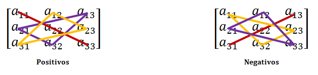

Regla de Sarrus

Básicamente lo que dice la imágen es:

$$\det(A) = a_{11}a_{22}a_{33}+a_{21}a_{32}a_{13}+a_{31}a_{12}a_{23}$$
$$-a_{13}a_{22}a_{31}-a_{23}a_{32}a_{11}-a_{33}a_{12}a_{21}$$

Del lado positivo se piensa con $a_{11}a_{22}a_{33}$ en diagonal, a continuacion la paralela $a_{21}a_{32}a_{13}$ y despues la otra $a_{31}a_{12}a_{23}$, esos son los que se multiplican y despues se suman, asi tambian con los de lado negativo, estos se restan desues de realizar las operacion de arriba que son los de los positivos

Los determinantes son un numero que nos describen una serie de propiedades y estos proceden de una deficion recursiva y para calulcalarla **Ejemplo** de una matriz 20x20 se tienen que calcular todos los 19 x 19 que salen de la primera fila para cada uno de ese 19 se tiene que calcular de 18 x 18 y asi sucecivamente por eso es recursiva y al final el numero del determinante tienen propiedades que se relacionan con el sistema de ecuaciones y las matrices inversas

**una de esa Propiedades** Para cualquier numero *n* mayor o igual que $1$ $\forall n\ge1$, el determinante de la transpuesta de una matriz $A\in\mathcal{M}_n(\mathbb{K})$ coincide con el determinante de dicha matriz,
$$\det(A^t) = \det(A)$$
, el determinante de la transpuesta es igual al determiante de la matriz A

**Ejercicio 1**

- En primer lugar, probad que es cierto para los casos particulares $n = 2$ y $n = 3$
- Demostrad formalmente este resultado para el caso general

Empezando con **n = 2**

$$A = \begin{pmatrix}a_{11} & a_{12}\\a_{21} & a_{22}\end{pmatrix}$$
$$det(a) = a_{11}\alpha_{11} - a_{12}\alpha_{12} = a_{11}a_{22} - a_{12}a_{21}$$
Sacando su Transpuesta y el determinante de esta:

$$A^t = \begin{pmatrix}a_{11} & a_{21}\\a_{12} & a_{22}\end{pmatrix}$$
$$det(a^t) = a_{11}\alpha_{11} - a_{21}\alpha_{21} = a_{11}a_{22} - a_{21}a_{12}$$
Vemos que es lo mismo

Debido a esto, tenemos las siguientes propiedades

## 1° Propiedades de los determinantes

Denotemos que cunado escriban como $\det(u_1,\dots,u_i,\dots,u_n)$ queremos decir que el determinante de la matriz $A\in\mathcal{M}_n(\mathbb{K})$, la cual tiene por filas (o columnas) los vectores $u_n$, por que como la transpuesta es igual por eso es igal por filas o columnas $u_i,\ i = 1,2,\dots,n$

**Propiedad** $\det(u_1,\dots,\lambda u_i,\dots,u_n) = \lambda\det(u_1,\dots,u_i,\dots,u_n)$, esto dice que toda una fila o columna multiplicada por Lambda, ese escalar puede dalir fuera del determinante

**Ejemplo 3**

con las barras verticles indicamos el determinante ya no se usa parentesis

$$\begin{vmatrix}1&2&1\\4&4&2\\10&4&1\end{vmatrix} = 2\begin{vmatrix}1&\mathbf{1}&1\\4&\mathbf{2}&2\\10&\mathbf{2}&1\end{vmatrix} = 4\begin{vmatrix}1&1&1\\\mathbf{2}&\mathbf{1}&\mathbf{1}\\10&2&1\end{vmatrix}$$
Vemos que de la segunda columna en la primera matriz de la igualdad todos son multiplos de dos factor comun que se pone fuera del determinante, la segunda columna se queda ahora como **1 2 2**, y vemos que la segunda fila sigue siendo multiple de dos **4 2 2** si sacamos ese dos con el dos que ya teniamos afuera suman 4 y ahora cambia esa fila y hemos pasado a tener numeros mas pequeños

## 2° Propiedades de los determinantes

**Propiedad** $\det(u_1,\dots,u_i+u_i',\dots,u_n) = \det(u_1,\dots,u_i,\dots,u_n)+\det(u_1,\dots,u_i',\dots,u_n)$, si a una fila o columna esta expresada como suma de dos posibles vectores se traduce que es el determinante de dos matrices diferentes en la cual una se lleva la primera fila o columna y la otra la segunda, seria la suma de dos determinantes

**Ejemplo 4**

Este es una ejemplo muy explicito

$$\begin{vmatrix}1&0+3&-1\\2&2+2&3\\0&3+1&5\end{vmatrix} =
\begin{vmatrix}1&0&-1\\2&2&3\\0&3&5\end{vmatrix}+\begin{vmatrix}1&3&-1\\2&2&3\\0&1&5\end{vmatrix}$$

se ah expresado la columna de este derterminante como suma de dos numeros y vemos como se puede escribir como la suma de dos determinantes, donde el de la izquierda se lleva la primera parte del sumando de la segunda columna y el segundo determinante se lleva la segunda parte de la suma y el resto de columnas permanecen iguales

**Propiedad** Si se intercambian dos filas o columnas de orden, el determinante cambia de signo: $\det(u_1,\dots,u_i,\dots,u_j,\dots,u_n) = -\det(u_1,\dots,u_j,\dots,u_i,\dots,u_n)$, vemos como se cambio de orden la $u_{i} u_j$ entonces cambia de signo

**Ejemplo 5**

$$\begin{vmatrix}1 & 0 & -2\\2&3&0\\-1&1&0\end{vmatrix} =
- \begin{vmatrix}-1 & 1 & 0\\2&3&0\\1&0&-2\end{vmatrix} =
\begin{vmatrix}1 & -1 & 0\\3&2&0\\0&1&-2\end{vmatrix}$$

De este determinante hemos cambiado la fila de abajo y la hemos puesto arriba y el determinante cambia de signo, si volvemos a cambiar en este caso la primera y segunda columna y vuelve a cambiar de signo, **Solo se puede cambiar de dos en dos NO mas**

**Propiedad** Si una matriz tiene dos filas o columnas iguales, su determinante es 0: $\det(u_1,\dots,u_i,\dots,u_i\dots,u_n)=0$

**Ejercicio 2**

Buscad vosotros mismos dos ejemplos cualesquiera, uno de orden 2 y otro de orden 3 y comprobad que, efectivamente, se cumple la propiedad enunciada, Se puede comprobar aplicando la formula del determinante dos por dos o la regla de sarrus

**Propiedad** Como consecuencia de lo anterior, Si una matriz tiene dos filas o columnas **NO iguales** pero proporcionales, su determinante es 0: $\det(u_1,\dots,u_i,\dots,\lambda u_i\dots,u_n)=0$, seria tomar una de las filas o columnas y multiplicarlas por un escalar, una fila $u_i$ y del otro lado $\lambda u_i$

**Ejercicio 3**

Buscad vosotros mismos dos ejemplos cualesquiera, uno de orden 2 y otro de orden 3 donde una de las filas y columnas sea proporcionar ala otra **igual ala anterior pero multiplicada por un escalar** y comprobad que, efectivamente, se cumple la propiedad enunciada

**Propiedad** Si una fila o columna es combinación lineal de las otras, el determinante es nulo:

Si $u_i =\sum_{k\ne i}a_ku_k$, entonces $\det(u_1,\dots,u_i,\dots,u_n)=0$

quiere decir que si para una fila o columna $u_i$ se puede escribir como una $\sum$ sumatoria para $k\ne i$, es una combinacion lineal de las otras columnas $a_ku_k$, ejemplo: 7x1°fila + 8x4°fila - 27x8°fila,entonces el determinanate sera cero

**Ejemplo 6**

$$\begin{vmatrix}1 & 2 & 3\\4 & 0 & 2\\ 5&2&5\end{vmatrix}=0$$

La última fila es el resultado de sumar las dos primeras.**Se puede hacer la regla se Sarrus para desmostrar** que es =0, por la ultima fila tiene sumada la primera y segunda fila, **Pero No solo es sumar asi** tambien vale multiplicar por numeros como el ejemplo de arriba: ejemplo: 7x1°fila + 8x4°fila - 27x8°fila, en este caso ejemplo 3x1°Fila + 8x2°Fila

**Propiedad** El determinante no cambia si a una fila o columna se le suma una combinación lineal de las otras. $\det(u_1,\dots,u_i,\dots,u_n) = \det(u_1,\dots,u_i+\sum_{k\ne i}a_ku_k,\dots,u_n)$

Si tenemos el determinante $\det(u_1,\dots,u_i,\dots,u_n)$ como filas o clumnas de A y en un momento dado ala fila o columna $u_i$ le sumamos una combinacion lineal de las restantes el determinante no cambia: $\sum_{k\ne i}a_ku_k,\dots,u_n)$, es ${k\ne i}$ porque **No se le puede sumar a si misma ala fila o columna**

**Ejemplo 7**

$$\begin{vmatrix}1 & 2 & 3\\4 & 0 & 2\\ 5&-1&0\end{vmatrix} = \begin{vmatrix}1 & 2 & 6\\4 & 0 & 6\\ 5&-1&4\end{vmatrix}$$

A la tercera columna le hemos sumado la primera y la segunda columnas. como a este determinante le hemos sumado una combinacion lineal de las otras filas o columnas el determinante no cambia

**Despues de ver estas Propiedades**, podemos simplificar ala hora de hacer determinantes antes de hacer todos los calculos como la regla de Sarrus o las formulas como matrices mas grandes, ver tener el numero mas grande de ceros menos operaciones tenedremos que hacer

## Adjuntos y menores complementarios

Este es otro concepto que nos ayuda ala hora de calcular determinantes

Dada la matriz ${n\times n}$ y siempre que sea *Mayor o igual a 2* $A = (a_{ij})_{n\times n},\ n\ge2$. Sea $a_{ij}$ el elemento que ocupa la fila $i$ y la columna $j$ de la matriz $A$. Si eliminamos toda la fila $i$-esima y la columna $j$-eseima de $A$ que es donde se encuentra este elemento $a_{ij}$, como nuestra matriz es de orden $n$ obtendremos una matriz cuadrada de orden $n-1$

**Menor complementario** El menor complementario de $a_{ij}$ es el determinante de la matriz de orden $n-1$ que sale de eliminar $a_{ij}$ en generar tomando cualquier elemento del interior de la matriz tachamos la fila y columna de ese elemnto el determinante que resulta se llama como $\alpha_{ij}$ y se le denomina el menor complementario

**Adjunto** El elemento $A_{ij} = (-1)^{i+j}\alpha_{ij}$ es el adjunto del elemento $a_{ij}$, tachamos fila y columna y llevamos a cabo el subdeterminante que resulta de haber eliminado fila y columna **Este es el menor complementario** que es $\alpha_{ij}$ pero en este caso hay que multiplicarlo o bien por $1$ o $-1$, este $(-1)^{i+j}$ significa que tenemos que contar en que fila esta $i$ y en que columna esta $j$ si despues de hacer la suma nos da un numero impar nos saldra -1 y si es par es +1, la idea es que aldjunto tome el valor del menor complementario si la suma de la fila y columna es par y tomara el opuesto (cambia de signo) del menor complementario en caso de que la suma sea imapar, Al calcularlo en una matriz siempre dada una pocicion todas las de al lado (arriba,abajo,izquierda,derecha) tienen signo contrario, si en una pocicon tenemos una positivo en las de lado seran negativa

**Matriz adjunta de $A$** Matriz que tiene el mismo orden que la matriz original pero tiene como coeficientes los adjuntos $A_{ij}$ (los de arriba) de cada uno de los elementos $a_{ij}$ de la matriz original $A$. Se denota por $\text{Adj}(A)$, se debe de poner una matriz del mismo orden de la matriz original donde los nuevos coeficientes seran todos los adjuntos de la matriz original

**Ejemplo 8**

La matriz adjunta de
$$A = \begin{pmatrix}1 & 0 & 5\\-1&3&2\\ 0 & -1 & 1\end{pmatrix}$$
es

Pasara por calcular 9 menores complementarios, estos para calcularlos, el que tomamos tachamos fila y columna y vamos calculando los subdeterminantes dos por dos de la submatriz que nos quedan y asi susecivamente donde esta cada numero se saca, A continuacion el porque de los signos si unos tiene positivos y otros negativos

pero se ah dicho que la matriz de Adjuntos tiene adjuntos no menores complementarios enotnces hay que mirar si la suma de fila o columna es par o impar para cada uno de los elemntos, Ejemplo

para la primera submatriz: $\begin{vmatrix} 3 & 2\\ -1 & 1\end{vmatrix}$ **Aplicara para todas las matrices de adjuntos dependiendo en la pocicion en la que se encunetren**, primera fila + primera columna (1+1=2), Aplicando la formula $(-1)^{i+j}$, y el resultado nos dara si llevara un signo positivo o negativo para cada matriz de adjuntos, para el siguente: $\begin{vmatrix}-1 & 2\\ 0 & 1\end{vmatrix}$ primera fila segunda columna (1+2=3) y se aplica la formula, y asi para le siguente: $\begin{vmatrix}-1 & 3\\0 & -1\end{vmatrix}$ (priera fila tercera columna) (1+3=4), despues sigue la segunda fila y empieza con la primera columna y asi hasta temrinar de recorrer ara asignarles el signo aplcando la formula $(-1)^{i+j}$

en pocas palabras vemos como va cambiando, empezamos en $+$ y luego $-$, esto simepre sera asi cuando el numero $n$ de la matriz es un numero impar, cuando **NO** si fuera par no aplica

despues de aberles cambiado el signo segun la pocicion ya son adjuntos y si los calculamos a cada uno su determinantes, vemos el resultado $=$

$$\text{Adj}(A) =
\begin{pmatrix}
\begin{vmatrix} 3 & 2\\ -1 & 1\end{vmatrix} &
-\begin{vmatrix}-1 & 2\\ 0 & 1\end{vmatrix} &
\begin{vmatrix}-1 & 3\\0 & -1\end{vmatrix}\\
-\begin{vmatrix}0 & 5\\ -1 & 1\end{vmatrix} &
\begin{vmatrix}1 & 5\\ 0 & 1\end{vmatrix} &
-\begin{vmatrix}1 & 0\\ 0 & -1\end{vmatrix}\\
\begin{vmatrix}0 & 5\\ 3 & 2\end{vmatrix} &
-\begin{vmatrix}1 & 5\\-1 & 2\end{vmatrix} &
\begin{vmatrix}1 & 0 \\ -1 & 3\end{vmatrix}\\
\end{pmatrix} = \begin{pmatrix}5 & 1 & 1\\ -5 & 1 & 1\\-15 & -7 & 3\end{pmatrix}$$

todo es el adjunto que es importante para poder calcular la matriz inversa mas facil que el metodo de gauss

# Cálculo de determinantes

El determinante de una matriz cuadrada $A\in\mathcal{M}_n(\mathbb{K})$, $n\ge2$ se puede calcular desarrollando por los adjuntos de los elementos de cualquiera de sus filas o columnas:

la definicion sigue sieno la misma pero en este caso se nos da una propiedad

**Proposición.** Sea $A = (a_{ij})$ una matriz cuadrada de orden $n$. Entonces se verifica, Si A es una Matriz Cuadrada de orden N

Se desarrolla el determinante por todos los elemntos de una fila

$$\det(A) = a_{i1}A_{i1}+a_{i2}A_{i2}+\cdots+a_{in}A_{in}$$
, donde $a_i$ es la fila por el menor complementario de ese elemnto por el determinante $A_{i1}$

es decir que se puede desarrollar todo el determinante por los adjuntos de los elementos de una fila (nosotros elegimos una fila (solo una), la que se nos de la gana, recomendable la que tenga muchos cero para ahorrarnos las operaciones), escribimos el numero que hay en la fila, seria $a_i1$ multiplicado por el menor que resulta de tachar la fila y columna de ese numero **Recordar la formula para sacrle el signo** que es el determinante que resulta de tachar fila y columna $A_{i1}$ y asi sucecivamente como se muestra, (Arriba es para cualquier fila y esta de abajo es para cualquier columna)

se desarrolla el determinante por los adjuntos de todos los elemntos de una columna

$$\det(A) = a_{1j}A_{1j}+a_{2j}A_{2j}+\cdots+a_{nj}A_{nj}$$

que es el desarrollo de un determinante por los adjuntos de los elementos de una columna, elegimos cualquier columna y multiplicamos cada uno de los elemntos de esa columna por los adjuntos de ese elementos que resultan de tachar fila y columna segun donde se encunetra el elemnto por los menores + o - de $A_{nj}$

Esto seria hacer n determintas en lugar de nxm,

**Ejemplo 9**

El determinante

$$\det(A) = \begin{vmatrix}1 & -1 & 3\\4 & 0 & 2\\ 5&-1&0\end{vmatrix}$$

en este caso lo hemos desarrollado por los elementos de la primera fila es $1, -1, 3$, vamos a tomar el $1$ y lo multiplicaremo por el determinante de tachar fila y columna de este numero, abaja vemos los productos, A continuacion vendria el $-1$ pero esta en fila **impar** columna **par** y por eso se le coloca un menos antes del numero que es -1 y ponemos el detemrinante que forma

$$|A| = 1\begin{vmatrix}0 & 2\\-1&0\end{vmatrix}-(-1)\begin{vmatrix}4&2\\5&0\end{vmatrix}+3\begin{vmatrix}4 & 0\\5 & -1\end{vmatrix} = 1\cdot 2+1\cdot(-10)+3\cdot(-4) = -20$$
, con este desarrollo de la primera fila vemos los resultados de multiplicar ese numero y el resultado de desarrollar el determinante

y desarrollado por los elementos de la segunda columna es

aqui ya es mas facil porque ya tiene un 0, Empezamos en primera fila segunda columna, por lo que seria con negativo y sacamos su determinante, vemos que por el 0 ya no es nesesario calcularlo

$$|A| = -(-1)\begin{vmatrix}4&2\\5&0\end{vmatrix}+0\begin{vmatrix}1&3\\5&0\end{vmatrix}-(-1)\begin{vmatrix}1&3\\4&2\end{vmatrix} = 1\cdot (-10)+0+1\cdot(-10) = -20$$
, vemos que el resultado es igual

Aplicando este último desarrollo a las matrices triangulares o diagonales o que tengan muchos ceros, tenemos que el determinante de una de estas matrices es igual al producto de los elementos de la diagonal principal

**Ejemplo 10**

Esta matriz triangular superior, vemos que si desarrollamos por la primera columna, de las cuatro operaciones solo tendriamos que hacer una, igual csi elegimos la cuarta fila

$$\det(A) = \begin{vmatrix}1 & 2 & 3 & 4\\
0 & 5 & 6 & 7\\
0 & 0 & 8 & 9\\
0 & 0 & 0 & 10\end{vmatrix} = 1\begin{vmatrix}5 & 6 & 7\\
0 & 8 & 9\\
0 & 0 & 10\end{vmatrix} = 5\begin{vmatrix}
8 & 9\\
0 & 10\end{vmatrix} = 40|10| = 400$$

Lo que hemos hecho ha sido hacer un desarrollo por los adjuntos de la primera columna en cada paso, como esta en pocicion impar e impar por lo tanto esta pocitivo por el determinante que resulta de tachar la fila y columna de este numero, **Pero AHORA podemos volver a repetir el proseso** elegimos la columna donde esta el 5 tenesmo todos ceros por eso asi solo ponemos un determinante, el 5 lo multiplicamos por el 1 que ya estaba y sacamos el resultado de tachar la fila y columna de este 5, **Podriamos volver a repetir el proceso o sacarlo directamente**, en este caso sacamos la columna del 8, lo multiplicamos por el 5, tachamos la fila y columna y finalmente nos queda $40|10| = 400$, a cada paso hemos tenedi menos elemntos hasta llegar a una matriz 1x1, y por regla es el mismo numero que contienen la matriz el detemrinante por eso solo se multiplico

**Ejemplo 11**

A continuación os presentamos el determinante de Vandermonde de orden 4, **Aplica para resolver un determinante 4x4**

$$\begin{vmatrix}1 & 1 & 1 & 1\\
a & b & c & d\\
a^2 & b^2 & c^2 & d^2\\
a^3 & b^3 & c^3 & d^3\end{vmatrix}$$

tenemos primero toda una fila de $1$, desoues toda una fila de numeros,en la siguente sus cuadrados y en la siguente sus cubos, este determinante se puede hacer en orden nxn, tambien se puede cumplir si tubieramos toda una de columna de puros 1

**Recordar Truco:** si tomamos una fila o columna y le sumamos una combinacion lineal de otra, el determinante se queda igual, asi si permutamos dos filas o columnas el determinante cambia de signo

Con todo lo que hemos visto hasta ahora, podemos resolverlo de forma sencilla:

En primer lugar como en este caso, tomamos la fila 4 y la restamos por la 3° fila multiplicada por a, realizamos $f_4-af_3$ el determinante no cambiara

$$\begin{vmatrix}1 & 1 & 1 & 1\\
a & b & c & d\\
a^2 & b^2 & c^2 & d^2\\
a^3 & b^3 & c^3 & d^3\end{vmatrix} = \begin{vmatrix}1 & 1 & 1 & 1\\
a & b & c & d\\
a^2 & b^2 & c^2 & d^2\\
0 & b^3-ab^2 & c^3-ac^2 & d^3-ad^2\end{vmatrix}$$

hemos hecho un 0, en esa pocicion, nuestro objetivo es hacer 0 tantos como pueda por debajo del 1 de la primera columna

A continuación para poder hacer un cero en la $a^2$, $f_3-af_2$

$$=\begin{vmatrix}1 & 1 & 1 & 1\\
a & b & c & d\\
0 & b^2-ab & c^2-ac & d^2-ad\\
0 & b^3-ab^2 & c^3-ac^2 & d^3-ad^2\end{vmatrix}$$

Ahora realizamos $f_2-af_1$ para carganos la ultima $a$ y asi tener ceros pues obtenemos

$$=\begin{vmatrix}1 & 1 & 1 & 1\\
0 & b-a & c-a & d-a\\
0 & b^2-ab & c^2-ac & d^2-ad\\
0 & b^3-ab^2 & c^3-ac^2 & d^3-ad^2\end{vmatrix}
=\begin{vmatrix}1 & 1 & 1 & 1\\
0 & b-a & c-a & d-a\\
0 & b(b-a) & c(c-a) & d(d-a)\\
0 & b^2(b-a) & c^2(c-a) & d^2(d-a)\end{vmatrix}$$
, vemos pque por las otras columnas todos los elementos en la segunda columna tienen una $b$ repetida en la tercera todos tienen una $c$ repetida y en la ultima esta la $d$ repetida, por lo tanto podemos sacar factor comun en cada una de las filas por columnas como se muestra arriba

hemos sacado factor comun porque vemos como en la segunda columna todas las filas a excepcion de la primer, tienen algo que se repite que es $b-a$,igual para la tercera que es $c-a$ y la cuarta $d-a$

El siguiente paso es desarrollar por la primera columna, al tener todos esos ceros en lugar de calcular todos los determinantes solo vamos hacer uno y haciendo las operaciones para sacarle el signo (primera fila, primera columna = 1+1 =2, $-1^2$=sale 1 positivo)

ponemos ese 1 positivo fuera y despeues el subdeterminante que resulta de tachar la fila y columna, nos queda este 3x3, pero despues de ponerlo gracias de haber sacado factor comun,toda la primera columna tiene $b-a$ como factor **Recordar la propiedad:** Que tida una columna esta multiplicada por un factor Lambda(Escalar), este escalar pueda salir fuera del Determinante, y esto aplica para las demas columnas que tambien podemos sacar $c-a$ y $d-a$

$$= 1\begin{vmatrix}b-a & c-a & d-a\\
b(b-a) & c(c-a) & d(d-a)\\
b^2(b-a) & c^2(c-a) & d^2(d-a)\end{vmatrix} = (b-a)(c-a)(d-a)\begin{vmatrix}1 & 1& 1\\b & c & d\\ b^2&c^2&d^2\end{vmatrix}$$

Hemos obtenido un determinante de Vandermonde de orden 3, (hemos pasado de uno 4x4). Lo que implica seguir el mismo razonamiento anterior para poder reducir las filas, **En este caso queremos hacer 0 donde esta la**$b$ y $b^2$:

Empezamos realizando $f_3-bf_2$, los factores que hemos sacado los seguimos ponendo

$$(b-a)(c-a)(d-a)\begin{vmatrix}1 & 1& 1\\b & c & d\\ b^2&c^2&d^2\end{vmatrix} = (b-a)(c-a)(d-a)\begin{vmatrix}1 & 1& 1\\b & c & d\\ 0&c^2-bc&d^2-bd\end{vmatrix}$$

A continuación, $f_2-bf_1$

$$= (b-a)(c-a)(d-a)\begin{vmatrix}1 & 1& 1\\0 & c-b & d-b\\ 0&c^2-bc&d^2-bd\end{vmatrix}$$

Finalmente, desarrollando de nuevo por la primera columna (en este caso el 1, se pone afuera positivo), despues el subdeterminnete que sale tachando fila y columna podemos ver para sacar factor común $(c-b)$ y $(d-b)$ de las dos últimas columnas obtenemos:

$$\det(A) = (b-a)(c-a)(d-a)(c-b)(d-b)\begin{vmatrix}1 & 1\\ c & d\end{vmatrix} = (b-a)(c-a)(d-a)(c-b)(d-b)(d-c)$$
Nos queda una matriz 2 x 2, yano es necesaria resolver por Vandermonder si no que podemos sacarla directmente el determinante que seria $d-c$, como resulta es el producto de todas las diferencias entre los elemntos de la priemra fila, todas las restas pocibles entre todos los elementos, si **tubieramos numeros** solo hay que restarlos y multiplicarlos entre si como se muestra en el resultado

# Aplicaciones en el cálculo de matrices y sistemas

Los determinantes nos sirven para facilitar el cálculo con matrices inversas sin Gauss y en la resolución de sistemas de ecuaciones lineales

Pasemos al calculo de la inversa

**Teorema** Sean $A$ y $B$ matrices cuadradas de orden $n$, $A,B\in\mathcal{M}_n(\mathbb{K})$. Entonces:

- $A$ es invertible si, y solo si, $\det(A)\ne 0$, lo principal para que tenga inversa (las matrices regulares son las que el determinante no es 0)
- $\det(AB) = \det(A)\det(B)$, el producto de dos matrices se puede hacer en lugar de hacer por separado pro matriz
- si $\det(A)\ne 0$, entonces El determinante de la inversa $\det(A^{-1}) = \frac{1}{\det(A)}$, esta biene directamtne por la de arriba, **una demostracion:** Si cambaimos la B como la Inversa de A $\det(AA^1)$ = esta nos da la identidad (esta solo tiene 1 en la diagonal) por lo que podemos usar por filas o clumnas usando los menor y ver que el determinante de la identidad es 1, entonces seria: $1 = \det(A)\det(A^1)$ y si despejamos esta formula nos queda que es igual a $\frac{1}{\det(A)}$
- si $\det(A)\ne 0$, entonces $A^{-1} = \frac{(\text{Adj}(A))^t}{\det(A)}$, Gracias a esta propiedad tenemos explicitamente como calcular la inversa de A, viendo la formula podriamos hacer prmero la transpuesta y despues la adjunta ya que las operaciones da lugarala misma matriz

**Observación** La última propiedad nos da una nueva forma de calcular la matriz inversa de $A$.

**Ejemplo 12**

Calculemos la inversa de la matriz
$$A = \begin{pmatrix}1 & 0 & -1\\ 0 & -3 & 5\\ 2 & -2 & 0\end{pmatrix}$$

En **primer lugar** saber que esta matriz tiene Inversa (Es que el determinante no sea $0$), calculemos el determinante de $A$ y veamos si es nulo o no. Por la Regla de Sarrus ya que hay muchos ceros en la matriz, despues de realizar os pasos nos queda:

$$\det(A) = 0 + 0 + 0 -(6-10+0) = 4\ne 0$$
, nos sale 4 que es diferente de 0 yacon esto podemos asegurar que existe la inversa de A

Con lo cual, sabemos que $A$ es invertible. Procedamos a calcular su inversa. En primer lugar, calculemos la matriz adjunta: (Vamos a necesitar calcular los 9 menores(adjuntos) de la matriz para calcular la matriz de adjuntos), tachamos fila y columna de cada numero segun la pocicion (Para saber si lleva un sigo pocitivo o Negativo) y caculamos su determinante directamente

$$A_{11} = \begin{vmatrix}-3 & 5\\-2 & 0\end{vmatrix} = 10\qquad A_{12} = -\begin{vmatrix}0 & 5\\2 & 0\end{vmatrix} = 10\qquad A_{13} = \begin{vmatrix}0 & -3\\2 & -2\end{vmatrix}=6$$
$$A_{21} = -\begin{vmatrix}0 & -1\\-2 & 0\end{vmatrix} = 2\qquad A_{22} = \begin{vmatrix}1 & -1\\ 2 & 0\end{vmatrix} = 2\qquad A_{23} = -\begin{vmatrix}1 & 0\\ 2 & -2\end{vmatrix} = 2$$
$$A_{31} = \begin{vmatrix}0 & -1\\-3 & 5\end{vmatrix} = -3\qquad A_{32} = -\begin{vmatrix}1 & -1\\0 & 5\end{vmatrix} = -5\qquad A_{33} = \begin{vmatrix}1 & 0\\0 & -3\end{vmatrix} = -3$$

Despues de hhaber sacado los 9 menores ya podemos ponerlor como la matrizde Adjuntos con cada uno de esos digitos

Por tanto,
$$\text{Adj}(A) = \begin{pmatrix}10 & 10 & 6\\
2 & 2 & 2\\
-3 & -5 & -3\end{pmatrix}$$

Ahora, su transpuesta es

$$(\text{Adj}(A))^t = \begin{pmatrix}10 & 2 & -3\\
10 & 2 & -5\\
6 & 2 & -3\end{pmatrix}$$

Ya tenems la Adjunta Transpuesta por lo que para calcular su Inversa solo tenemos que Dividir por el determinante de A **Este ya lo calculamos en el primer paso que es 4 (verificamos que no sea 0)** asi Finalmente, (Multiplicar por un 1/4 o dividir por 4 todos los elemnots del interior de la matriz)
$$A^{-1} = \frac{1}{\det(A)}(\text{Adj}(A))^t = \frac{1}{4}\begin{pmatrix}10 & 2 & -3\\
10 & 2 & -5\\
6 & 2 & -3\end{pmatrix} = \begin{pmatrix}\frac{5}{2} & \frac{1}{2} & -\frac{3}{4}\\
\frac{5}{2} & \frac{1}{2} & -\frac{5}{4}\\
\frac{3}{2} & \frac{1}{2} & -\frac{3}{4}\end{pmatrix}$$

Si multiplicamos esta matriz por la matriz original de A nos tiene que salir la identidad o si la hacemos por Gauss nos tiene que dar el mismo resultado

## 2° Aplicacion en el cálculo de matrices y sistemas

Otra aplicación de los determinantes se encuntra en el cálculo del rango de una matriz:

Dada $A\in\mathcal{M}_{m\times n}(\mathbb{K})$ y sea $k<m,n$, vamos a elegir un numero $k$ menor que el numero de filas$m$ y columnas$n$

**Se llama Menor de orden** $k$ de $A$. Al Determinante de cualquier matriz cuadrada de orden $k$ obtenida suprimiendo $m-k$ filas y $n-k$ columnas de $A$, obtenemos este eligidendo $k$ filas y $k$ columnas de la Matriz A, este es un Determinante que se obtiene apartir de la matriz original

**Se llama Orlar un menor de orden** $k$. Con ese Menor de orden $k$ Consiste en completarlo hasta un menor de orden $k+1$ de $A$ con otra fila y otra columna de la matriz $A$ dada.Añadimos una fial y columna al Menor de orden $k$ y se vuelve $k+1$

Se pueden utilizar dichos menores para calcular el rango de una matriz $A$ cualquiera:

**Teorema** Sea $A\in\mathcal{M}_{m\times n}(\mathbb{K})$ y $k<m,n$. Entonces, si se puede encontrar un menor de orden $k$ no nulo dnetro de la matriz original (que podemos encontrar un subdeterminante $k$filas y columnas que no da 0) y todos los de orden $k+1$ que se obtienen al Orlar el menor anterior son 0, entonces $rg(A)= k$, En otras Palabras si el determinante mas grande que podemos obtener en el interior de la matriz A el menor de mayor orden que podemos encontrar esde orden $k$ y no es 0 entonces el rango de la matriz es $k$

En otras palabras, el rango de la matriz $A$ coincide con el orden del mayor menor no nulo obtenido a partir de $A$.

Otra forma de enunciar el `Teorema` anterior es la siguiente:

**Teorema** Sea $A\in\mathcal{M}_{m\times n}(\mathbb{K})$ y $k<m,n$. Entonces, si se puede encontrar un menor de orden $k$ no nulo y todas las posibles maneras de orlar dicho menor dan menores de orden $k+1$ nulos (todos los determinantes (k+1)x(k+1) que salen a partir de orlar el de orden k que no era 0 son nulos enotnces el rango de A es $k$), entonces $rg(A)= k$

**Ejemplo 13**

Calculemos el rango de la matriz
$$A = \begin{pmatrix}4 & 3 & 2 & -1 & -2\\ 7 & 5 & 4 & -2 & 1\\ 2 & 1 & 1 & -1 & 8\end{pmatrix}$$

**Hay que encontrar el mayor menor de la matriz que no sea nulo**, El mayor menor de la matriz $A$ es de orden 3 en este caso podriamos decir que el rango es directamtne 3, no puede ser 4 porque no tenemos 4 filas lo mismo con 5, lo maximo es rango 5. De hecho, esta matriz tiene ${5\choose 3} = 10$ menores de orden $3$ diferentes (los menores seria la forma de elegir las columnas, Las filas la elegimos todas si queremos de orden 3 porque solo hay 3 filas, pero las formas de elegir las columnas hay 10 formas diferentes porque hay 5 opciones de las cuales queremos elegir 3 (5/3)=10 ). Veamos si alguno de ellos es no nulo: Nos vasta con encontrar uno que no sea 0, si l calculamos no da 0 si no que da 1

$$(c_1,c_2,c_3) = \begin{vmatrix}4 & 3 & 2\\ 7 & 5 & 4\\ 2 & 1 & 1\end{vmatrix} = 20 +14+24-(20+16+21) = 1\ne 0$$

Concluimos que hemo encontrado un menor de orden 3 no nulo y todos los que habria en este caso no es posible de orden superior porlo que se concluye que es de rango 3

Como este menor de orden 3 ya no es nulo, por el Teorema anterior concluimos que la matriz tiene rango 3.

**Ejercicio 4.** Calcular el rango de la matriz (se recomeinda ir de pequeño a grande si el determinante 0 1 4 -2 un menor 2 x 2 no da cero ya vemos que espocible un rango de 2 y la idea es orlar (añadir una nueva fila (podemos elegir) o columna(solo tenemos una a elegir)), de aqui nos saldrian 3 determinantes 3 por 3, si lo hacemos y no da 3 ya esta el rango es 3 y no puede ser 4 porque porque no hay 4 columnas pero si diera 0 ya nos vamos a elegir la otra fila posivle y si llega a dar 0, por lo tanto el rango de la matriz seria 2)
$$A = \begin{pmatrix} 0 & 1 & -1\\ 4 & -2 & -6\\
-1 & 1 & 1\\
2 & -2 & -2\end{pmatrix}$$

Queremos rg(A), A tiene 4 filas y 3 columnas por lo tanto el mayor determinante sera de orden 3, asi sera que el rango solo podra ser menor o igual a 3, tomamos un elemnto distinto a cero: El $1$ de la segunda columna, vamos a orlar a un determinante de orden 2, Tomamos la primera fila y la primera columnas con la segunda fila y segunda columna, entonces vamos a calcular:

$$det(A) = \begin{vmatrix}0 & 1\\ 4 & -2\end{vmatrix} = -4$$
, vemos que es distinto de 0, por lo que ahora vamos a orlar este determinante, solo podemos cojer la tercera columna pero podemos elegir entre dos filas: ya elegida y aplicada la regla de sarrus

$$det(A) = \begin{vmatrix}0 & 1 & -1\\ 4 & -2 & -6\\ -1 & 1 & 1\end{vmatrix} = -4+6+2-4 = 0$$
, por este cero ahora tenemos que elegir la ota fila

$$det(A) = \begin{vmatrix}0 & 1 & -1\\ 4 & -2 & -6\\ 2 & -2 & -2\end{vmatrix} = 8-12-4+8 = 0$$
, nos vuelve a dar 0

entonces orlado de estos es 0 por lo tanto el unico valido es el primero que nos dice que el rango es 2

## Aplicaciones en el cálculo de matrices y sistemas

Otra aplicación muy útil de los determinantes es la de resolver sistemas de ecuaciones lineales.

Dado el sistema $AX = b$ en su expresión matricial, siendo éste un sistema de $n$ ecuaciones con $n$ incógnitas $x_1,\dots,x_n$. Sabemos que si $\det(A)\ne 0$ este sistema tiene solución única dada por despejar la inversa de A en la exprecion anterior $X = A^{-1}b$.

En estos casos, otra forma de encontrar esta solución única de un sistema compatible determinado con mismo numero de ecuaciones e incgnitas que es a través de la **Regla de Cramer**

**Teorema. Método de Cramer** Sea $AX = b$ la expresión matricial de un sistema de $n$ ecuaciones con $n$ incógnitas $x_1,\dots,x_n$ con $\det(A)\ne 0$. Sea $A_i,\ i=1,2,\dots,n$ la matriz que resulta de sustituir la columna $i$ de la matriz de coeficientes $A$ por el vector de términos independientes $b$. Entonces, la solución del sistema viene dada por
$$x_i = \frac{|A_i|}{|A|},\ \forall i = 1,2,\dots,n$$
, $|A_i|$ es la misma matriz de coeficientes pero en la columna $i$ se quita la que estaba y se a puesto el vector de terminos independientes por el ejemplo hemos puesto la $b$ en la columna $i$,hacemos su determinante y se divide cada uno por el determinante de A, esto se tiene que hacer para cada una de la variables por tanto se tiene que hacer n veses

**Ejemplo 14**

Consideremos el sistema $AX = b$ dado por
$$A = \begin{pmatrix}
1 & 1 & 1\\ -1 & 0 & 1\\ -1 & -1 & 0\end{pmatrix}\qquad X = \begin{pmatrix}x_1\\x_2\\x_3\end{pmatrix}\qquad b = \begin{pmatrix}1\\ 0\\ -1\end{pmatrix}$$

Primeramente a comprobar **Que el sistema es compatible determinado**, para eso se calcula el rango de A o lo que es lo mismo verificar que el determinante de A no sea Nulo, fácilmente que

$$\det(A) = \begin{vmatrix}
1 & 1 & 1\\ -1 & 0 & 1\\ -1 & -1 & 0\end{vmatrix} = 1\ne 0$$

Por tanto, tenemos un sistema que podemos resolver con Cramer con solución única dada por

$$x_1 = \frac{\begin{vmatrix}
1 & 1 & 1\\ 0 & 0 & 1\\ -1 & -1 & 0\end{vmatrix}}{|A|} = \frac{0}{1} = 0$$

$x_1$ es igual al determinante de la matriz de coeficientes, donde en lugar de la primera columna le ponemos el vector $b$, si hacemos ese determinante nos da cero dividido con 1 es igual a 0

para la siguente incognita, tomamos el vector $b$ y lo ponemos en la segunda columna, si hacemos ese determninanante nos da uno

$$x_2 = \frac{\begin{vmatrix}
1 & 1 & 1\\ -1 & 0 & 1\\ -1 & -1 & 0\end{vmatrix}}{|A|} = \frac{1}{1} = 1$$

en la tercera incognita tomamos el vector $b$ se coloca en la tercera columna porque es la que corresponde a $x_3$ y las demas columnas son las misma de la matriz original

$$x_3 = \frac{\begin{vmatrix}
1 & 1 & 1\\ -1 & 0 & 0\\ -1 & -1 & -1\end{vmatrix}}{|A|} = 0$$

Con lo cual, nuestra solución es
$$X = \begin{pmatrix}0\\1\\0\end{pmatrix}$$

**Ejercicio 5**

Demostrar que el sistema $AX = b$ dado por

$$A = \begin{pmatrix}
1 & 1 & 1\\ -1 & 0 & 1\\ -1 & -1 & 0\end{pmatrix}\qquad X = \begin{pmatrix}x_1\\x_2\\x_3\end{pmatrix}\qquad b = \begin{pmatrix}\alpha\\ \beta\\ \gamma\end{pmatrix}$$

con $\alpha,\beta,\gamma\in\mathbb{R}$ tiene solución única (Es compatible determinado lo cual solo depende de la matriz A o lo que es lo mismo que el rango de la matriz es 3 o que su determinante no es 0) y calcular dicha solución haciendo uso del Método de Cramer

**1° Demostrar que el sisitema tiene solucion unica**

Recordando el teroema de Rouself Robenius nos decia que un sistema era compatible determinado si y solo si el rango de la matriz A y el de la Matriz Ampleada del sistema coincidian y ademas tiene el mismo numero de incognitas por eso hay que demostrar que: $rg(A)=3$ y el de la Ampleada $rg(A|B)=3$ y con esto ya tenemos que el sistema sin importar el valor de $\alpha,\beta,\gamma\in\mathbb{R}$ es seimpre compativle determinado

Empezando con A: como solo es pocible que el rango sea 3 vamos a empezar por yatomar las tes filas y las tres columnas para sacarl el edeterminante y comprobar que no sea 0 (lo hacemos por la regla se Sarrus):

$$det(A) = \begin{vmatrix}
1 & 1 & 1\\ -1 & 0 & 1\\ -1 & -1 & 0\end{vmatrix} = 1-1-(-1) = 1$$
, con esto ya tenemos demostrado que el rango es 3

Ahora con la matriz Ampliada

$$det(A|B) = \begin{vmatrix}
1 & 1 & 1 & | & \alpha\\ -1 & 0 & 1 & | & \beta\\ -1 & -1 & 0 & | & \gamma\end{vmatrix}$$

queremos demostrar que el rango de esta matriz es 3 pero aqui tenemos que Siempre se va cumplir que: **que el rango de la ampliada es el rango de A o el rango de A+1**, por lo tanto esta matriz nunca podra tener rangos mayor a 3 porque solo tiene 3 filas automaticamente tenemos que el rango de la ampliada es 3, $rg(A|B) = 3$, independiente de los valores de $\alpha,\beta,\gamma$, se compuera con el teorema de rousell que el sistema es compatible determinado

**Ahora hay que resolver el sistema por el metodo de cramer**, ya sabemos que el determinante de A es 1

Tomamos la primera incognita, sustituimos el vector de terminos de terminos independientes en su pocicion que es la primera columna en la matriz y la dividimos por el determinante de la matriz que es 1, (Por lo que solo resolvemos el determinante que se nos formo con el vector de terminos independientes)

$$x_1 = \frac{\begin{vmatrix}
\alpha & 1 & 1\\ \beta & 0 & 1\\ \gamma & -1 & 0\end{vmatrix}}{1} = -\beta+\gamma-(-\alpha) = \alpha - \beta + \gamma$$

Lo mismo para la segunda y tercera incognita

$$x_2 = \frac{\begin{vmatrix}
1 & \alpha & 1\\ -1 & \beta & 1\\ -1 & \gamma & 0\end{vmatrix}}{1} = -\gamma-\alpha-(-\beta+\gamma) = -\alpha + \beta - 2\gamma$$

$$x_3 = \frac{\begin{vmatrix}
1 & 1 & \alpha\\ -1 & 0 & \beta\\ -1 & -1 & \gamma\end{vmatrix}}{1} = \alpha-\beta-(-\beta-\gamma) = \alpha + \gamma$$

Nuestra solucion sera:

$x_1 = \alpha - \beta + \gamma$

$x_2 = -\alpha + \beta - 2\gamma$

$x_3 = \alpha + \gamma$

La regla de Cramer también sirve en el caso de **sistemas compatibles indeterminados.**

Lo que se debe hacer en estos casos es encontrar un menor no nulo que nos dé el rango del sistema y la submatriz el sistema correspondiente a este menor es una matriz cuadrada invertible a la que se le puede aplicar el Método de Cramer.

Entonces, las ecuaciones no correspondientes a este menor las podemos eliminar, pues son prescindibles.

el truco es lo siguente, se definen:

**Incógnitas principales.** Las incógnitas involucradas en la submatriz, en ese menor no nulo que vamos a usar para hacer cramer

**Incógnitas secundarias.** Las incógnitas que no son principales. (las que no aparesen en ese menor)

De este modo, el sistema con las incógnitas principales y solo las ecuaciones correspondientes al menor no nulo seran las involucradas para poder hacer la matriz con cramer, tiene solución única dada por el Método de Cramer en función de las incógnitas secundarias.

**Ejemplo 15**

Consideremos el sistema $AX = b$ donde
$$A = \begin{pmatrix}
12 & 6 & 8\\
4 & 2 & 4\\
-8 & -4 & -4
\end{pmatrix}\qquad
X = \begin{pmatrix}
x\\
y\\
z\end{pmatrix}\qquad
b = \begin{pmatrix}
1\\
2\\
1\end{pmatrix}$$

Es fácil comprobar que al ahacer el determiannte de esta matriz
$$\det(A) = \begin{vmatrix}
12 & 6 & 8\\
4 & 2 & 4\\
-8 & -4 & -4
\end{vmatrix} = 0$$

nos da 0 ya que la primera columna es el doble de la segunda. Eso quiere decir que estas columnas son linealmente dependientes

Por este motivo, consideremos el menor de orden 2 formado en este caso por las dos primeras filas y las dos últimas columnas:

$$\begin{vmatrix}
6 & 8\\2 & 4
\end{vmatrix} = 8\ne 0$$
, haciendo el determinante de este menor es 8 diferente de 0, el rango de esta matriz es 2 porque el unico 3x3 con el que podriamos orlar este menor de 2x2 nos da el cero que anteriormente nos salio

Tambien si Orlando este menor con la columna de los términos independientes, lo que obtenemos es
$$\begin{vmatrix}
6 & 8 & 1\\2 & 4 & 2\\ -4 & -4 & 1
\end{vmatrix} = 0$$
que vuelve a dar cero y afirmamos que el rango de la matriz ya mpleada coinciden y el rango es dos

Por lo tanto, concluimos que $rg(A) = 2$. Además, tenemos que el sistema es compatible indeterminado.

Así pues, las incógnitas principales (van a ser las dos que aparecen en el menor subdeterminete que escogimos para calcular el rango) serán $y,z$ porque recordemos que el menor de orden 2 no nulo está formado por las dos últimas columnas de $A$.

Por otro lado, la tercera ecuación, al no haberla considerado en el menor de orden 2, ya no nos es necesaria. Así, nuestro sistema lo podemos reescribir como

$$\left\{\begin{matrix}
12x&+&6y&+&8z&=&1\\
4x&+&2y&+&4z&=&2
\end{matrix}
\right.$$
, recordando que las incognitas principales van a ser la $y$ y la $z$

o, equivalentemente, para resolver usando cramer **El truco esta que**, las variables secundarias pasan al termino independiente

$$\left\{\begin{matrix}
6y&+&8z&=&1-12x\\
2y&+&4z&=&2-4x
\end{matrix}
\right.$$

y este ahora es un sistema de Cramer de la forma $A'X' = b'$, donde $A'$ es la nueva matriz de coeficientes (vemos que con la matriz de arriba solo le eliminamos las letras para sacar esta antes del igual), el vector $X'$ es del que vamos a encontrar las soluciones y $b'$ es el vector de terminos independientes con

$$A' = \begin{pmatrix}
6 & 8\\
2 & 4
\end{pmatrix}\qquad X' = \begin{pmatrix}
y\\
z\end{pmatrix}\qquad b' = \begin{pmatrix}
1-12x\\
2-4x\end{pmatrix}$$

Y este sistema tiene solución única en función de $x$ (va a depender la variable x) la cual la podemos calcular dada por

la variable $y$ es el determinante de la matriz de coeficientes donde la primera columna que es donde estaba la $y$ ahora ponemos el vector de terminos independientes, dividimos por 8 que era el determinante de esta matriz 2x2

y para la z dejamos lo coeficientes de la primera columna y remplazamos los de la segunda que es donde esta la z pro el vector de terminos independientes y realizamos el determinante, dividimos entre 8

$$y = \frac{\begin{vmatrix}1-12x & 8\\
2-4x & 4\end{vmatrix}}{8} = \frac{-16x-12}{8} = -2x-\frac{3}{2}\qquad z = \frac{\begin{vmatrix}6 & 1-12x\\
2 & 2-4x\end{vmatrix}}{8} = \frac{10}{8}=\frac{5}{4}$$

De este modo, nuestra solución de este nuevo sistema es $X = \begin{pmatrix}x\\ -2x-\frac{3}{2}\\ \frac{5}{4}\end{pmatrix}$ con $x\in\mathbb{R}$, pero recordad que el sistema original tenia tres variables por lo que la x es una variable libre que puede tomar cualquier conjunto de valores, solo la Y y la Z esta ligadas a un valor

## Aplicaciones en el cálculo de matrices y sistemas

A la hora de calcular el rango de una matriz, calcular la inversa de una matriz regular o de resolver un sistema de ecuaciones lineales podemos hacerlo de dos formas:

- A través de transformaciones lineales (por el metodo de gauss(este es el que implementan los ordenadores por las operaciones) o los determinantes(son mas flexibles en las operaciones y se pueden aplicar mas propiedades y por los parametros no todos son numeros))
- Utilizando determinantes

La primera tiene la ventaja de la implementación en ordenadores ya que requiere de muchas menos operaciones.

En cambio, los determinantes permiten más flexibilidad en las operaciones, la cual es de agradecer cuando el estudio a hacer depende de uno o más parámetros.

**Ejercicio 6**

Estudiar el siguiente sistema según los valores del parámetro $a\in\mathbb{R}$

viendo a simple vista el sistema el rango puede ser de ciertos valores, vemos que si $a$ es igual a 1, las tres ecuaciones son iguales entonces dos de estas ecuaciones sobran y por eso se puede tratar de un sistema compatile indeterminado o los valores de $a$ pueden hacer que se trate de un determinado o en los casos es incompatible, para esto es mejor que calculemos el rango y en funcion de los valores de $a$ decidimos que tipo de sistema se trata

$$\left\{\begin{matrix}ax &+&y&+&z&=&1\\
x &+&ay&+&z&=&1\\
x &+&y&+&az&=&1\\
\end{matrix}\right.$$

En primer lugar empezemos calculando **el RANGO de la Matriz** de coeficientes del sistem, seria:

$$A = \begin{pmatrix}
a & 1 & 1\\
1 & a & 1\\
1 & 1 & a
\end{pmatrix}$$

para calcular lo haremos mediante Determinantes: En primer lugar saber cuando este determinante puede valor 0 osea cuando el rg(a) deja de ser 3

Calculamos el determinante

$$|A| = \begin{vmatrix}
a & 1 & 1\\
1 & a & 1\\
1 & 1 & a
\end{vmatrix} = a^3+1+1-(a+a+a) = a^3-3a+2$$

Ahora **Cuando puede esto Valer 0**, si hacemos los calculos, este determinante valdra 0 siempre y cuando

$a^3-3a+2 = 0$ – $(a-1)^2(a+2)=0$ – $a=1$ y $a=-2$

entonces nos quedan 3 casos

– Cuando $a$ sea difernete de $1$ y $-2$

– Cuando $a=1$

– Cuando $a=-2$

El primer caso, $a\ne 1$ y $a\ne -2$, es el más sencillo ya que al ser el determinante de $A$ no nulo, lo que tenemos es que tanto $A$ como la matriz ampliada del sistema tienen rango 3. Esto nos lleva a concluir que se trata de un sistema compatible determinado por el Teorema de Rouché-Frobenius.

Ahora, ¿qué ocurre cuando $a=1$? Pues, en primer lugar, que el rango de $A$ es estrictamente menor a 3 (porque el determinante de orden 3 vale 0), con lo cuál, veamos si es 2 o 1:

La matriz resultante de sustiruir Ax1 es;
$$A = \begin{pmatrix}
1 & 1 & 1\\
1 & 1 & 1\\
1 & 1 & 1
\end{pmatrix}$$

Como todas las filas y todas las columnas son iguales, entonces el rango de $A$ es 1, ya que no hay ningún determinante menor de orden 2 en esta matriz que sea no nulo. Porque segun las pripiedades como hay dos filas iguales esto es automaticamente un determinante igual a 0

Veamos qué ocurre con la ampliada:

$$A|b = \begin{pmatrix}
1 & 1 & 1 & 1\\
1 & 1 & 1 & 1\\
1 & 1 & 1 & 1
\end{pmatrix}$$

Pues ocurre exactamente lo mismo: todas las filas y todas las columnas son iguales. Entonces, por tanto el rango es 1. En este caso, por el Th. Rouché-Frobenius, como el rango de a es igual al rango de la Ampleada tenemos que se trata de un sistema compatible indeterminado (Indeterminado porque el rango es 1 y nosotros tenemos 3 incognitas).

Finalmente, si $a = -2$, tenemos lo siguiente,

$$A = \begin{pmatrix}
-2 & 1 & 1\\
1 & -2 & 1\\
1 & 1 & -2
\end{pmatrix}$$

Si tomamos el menor de orden 2 que es formado por las 2 primeras filas y las dos primeras columnas, tenemos que es no nulo, se nos forma esta submatriz de abajo y calculando su deerminante es

$$\begin{vmatrix}
-2 & 1\\
1 & -2
\end{vmatrix} = 4-1 =3\ne 0$$

con lo cual, el rango de la matriz de coeficientes del sistema es 2. ¿Qué ocurre ahora con el rango de la matriz ampliada?

ya tenemos un menor de orden 2 (diferente de 0) por lo que nos queda que orlamos el menor anterior, que ya hemos visto que no era nulo, con la última fila y la cuarta columna (porque ya sabemos que si tomamos la tercera columna el resultado va a ser 0, que es lo que calculamos desde el principio), lo que obtenemos es

$$\begin{vmatrix}
-2 & 1 & 1\\
1 & -2 & 1\\
1 & 1 & 1
\end{vmatrix} = 4+1+1-(-2-2+1) = 9\ne 0$$

Por tanto, acabamos de ver que el rango de la ampliada es 3 (Es diferene al de la matriz A), lo que nos lleva a concluir que, al ser los rangos diferentes, el sistema es incompatible

# Determinantes con `R`

## Ejemplo 1

La función `det()` es la que nos calcula el determinante de cualquier matriz cuadrada en `R`

**Ejemplo 1**

Calculemos el determinante de
$$A = \begin{pmatrix}
1 & 2\\
0 & -1
\end{pmatrix}\qquad B = \begin{pmatrix}
1 & 2 & 3\\
0 & -1 & 5\\
10 & 2 & -5
\end{pmatrix}$$

```r
# declaramos las matrices A y B
A = rbind(c(1,2), c(0,-1))
B = matrix(c(1,2,3,0,-1,5,10,2,-5), nrow = 3, ncol = 3, byrow = TRUE)
```

## Ejemplo 1

```r
# solo ejecutamos la Instruccion
det(A)
```

```
## [1] -1
```

```r
det(B)
```

```
## [1] 125
```

# Determinantes con `Python`

## Ejemplo 1

La función `numpy.linalg.det()` es la que nos calcula el determinante de cualquier matriz cuadrada en `Python`

**Ejemplo 1**

Calculemos el determinante de
$$A = \begin{pmatrix}
1 & 2\\
0 & -1
\end{pmatrix}\qquad B = \begin{pmatrix}
1 & 2 & 3\\
0 & -1 & 5\\
10 & 2 & -5
\end{pmatrix}$$

```python
import numpy as np
# las matrices se declaran con la misma libreria numpy
A = np.array([[1, 2], [0,-1]])
B = np.array([[1, 2,3], [0,-1,5], [10,2,-5]])
```

## Ejemplo 1

```python
# la funcion a usar y hemos usado un casting par que nos de un numero entero
int(np.linalg.det(A))
```

```
## -1
```

```python
int(np.linalg.det(B))
```

```
## 125
```